# Pitcher card

# Matt Strahm

LHP · KC

2026 · 41 G (0 GS) · 633 pitches · Mar 28 – Aug 01, 2026

Independent portfolio sample by Devin Jenkinson, not affiliated with any club. Every number is computed from public Statcast data.

Three big takeaways

1Attack

The 4-seam fastball is the put-away pitch. Use it to finish at-bats.

45% of two-strike pitches · 15% whiffs/swing (59 swings)

It grades 106 Stuff+. No other pitch has 50+ two-strike swings yet.

2Avoid

Limit the slider. It is his most damaging pitch.

xRV/100 -0.98 shrunk (raw -2.63) · .577 xwOBAcon · 177 pitches

When behind in the count he throws it 28% of the time; the 4-seam fastball grades +0.91 there instead.

3Watch

Use the 4-seam fastball up in the zone. It beats the league rate there.

33% whiffs/swing up (87 sw) vs 28% MLB FF up

61% of his 4-seam fastballs finish in the top third. Too few swings down (14) to compare.

Charts

### Movement

The SL finishes 24 in from his FF, with 20 in more glove-side run.

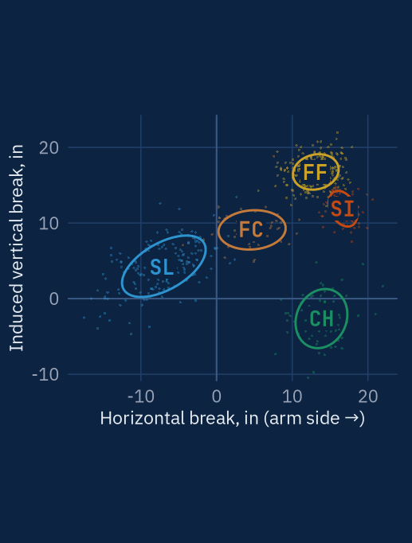

n = 633 pitches. Ellipses hold about 68% of each type; codes sit at the averages.

### Location by count

He fills the zone at about the same rate ahead (56%) and behind (56%).

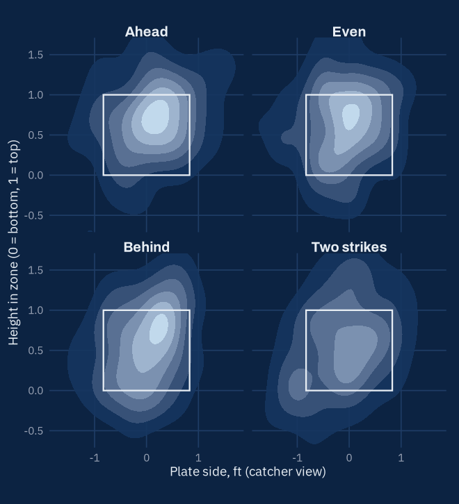

n = 633. Ahead 75 · even 219 · behind 138 · two strikes 201 pitches. Box = rule-book zone.

### Put-away

The FF is 45% of two-strike pitches vs 39% overall.

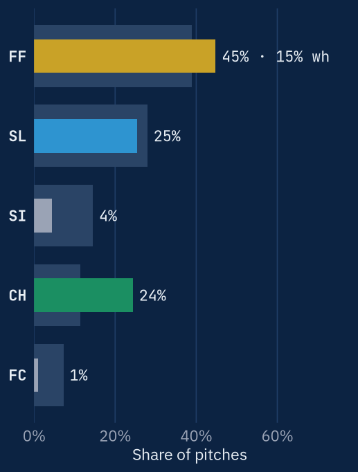

Two-strike n: FF 90, SL 51, CH 49, SI 9, FC 2. Grey bars = overall usage; wh = whiffs per swing (shown with 50+ swings).

### Arsenal

| Pitch | # | Use | Velo | IVB | HB | VAA | Whiff | Chase | xwOBAcon | xRV/100 | Stuff+ |
| --- | --- | --- | --- | --- | --- | --- | --- | --- | --- | --- | --- |
| 4-Seam (FF) | 246 | 39% | 91.3 | 16.8 | +13.0 | -4.1 | 26% | 33% | .302 | +0.91 | 106 |
| Slider (SL) | 177 | 28% | 81.2 | 4.2 | -7.2 | -7.0 | 28% | 31% | .577 | -0.98 | 103 |
| Sinker (SI) | 92 | 15% | 91.4 | 11.9 | +16.7 | -4.8 | 9% | 32% | .188 | +0.26 | 92 |
| Changeup (CH) | 72 | 11% | 82.3 | -2.6 | +13.9 | -7.7 | 17% | 38% | .211 | +0.02 | 101 |
| Cutter (FC) | 46 | 7% | 87.4 | 9.2 | +4.6 | -5.2 | 29% | 18% | .482 | -0.01 | 80 |

IVB / HB in inches (HB + = arm side). VAA in degrees at the front of the plate. xRV/100 = expected run value per 100 pitches, pitcher’s view, shrunk with a 250-pitch prior. Stuff+ = this project’s shape-only model (100 = MLB average, 10 = 1 SD).

### Vs. batter hand

| Pitch | LHH # | Use | Whiff | xwOBAcon | RHH # | Use | Whiff | xwOBAcon |
| --- | --- | --- | --- | --- | --- | --- | --- | --- |
| FF | 47 | 24% | – | .235 | 199 | 45% | 27% | .246 |
| SL | 72 | 37% | – | .440 | 105 | 24% | – | .474 |
| SI | 75 | 39% | – | .226 | 17 | 4% | – | .006 |
| CH | – | – | – | – | 72 | 16% | – | .256 |
| FC | – | – | – | – | 46 | 10% | – | .478 |

Use = share of pitches to that side. Whiff = whiffs per swing, shown with 50+ swings.